# Teacher Engagement Report

[figure not shown]

### YourDistrict USD School District

# Participant Profile

### Respondents within District

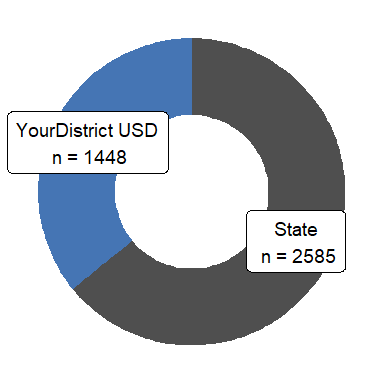

## YourDistrict USD = 36%

## Grade-Level Representation

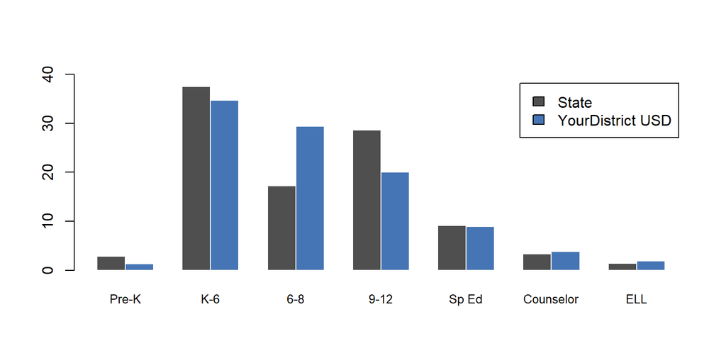

### Role in Education

**YourDistrict USD**, N = 1,448

Role Category, %

K-6

33%

30%

9-12

25%

17%

6-8

15%

25%

Sp Ed

8.0%

7.7%

SpEd-Prof

5.5%

9.3%

Counselor

2.9%

3.2%

Prof Serv

2.2%

1.9%

Pre-K

2.6%

1.1%

Read Sp

2.7%

0.8%

ELL

1.2%

1.7%

Soc Worker

0.8%

0.6%

Nurse

0.2%

1.1%

## Years in Education

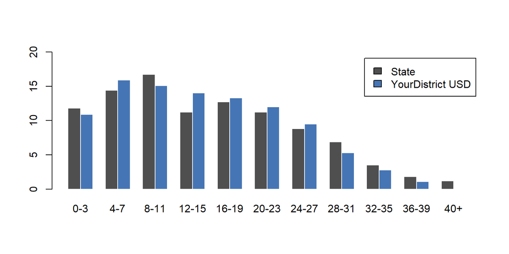

### Years Teaching

**State**, N = 2,585

**YourDistrict USD**, N = 1,448

Total Years, %

0-3

12%

11%

4-7

14%

16%

8-11

17%

15%

12-15

11%

14%

16-19

13%

13%

20-23

11%

12%

24-27

8.8%

9.5%

28-31

6.9%

5.3%

32-35

3.5%

2.8%

36-39

1.8%

1.1%

40+

1.2%

0.1%

(Missing)

3

0

## Years in District

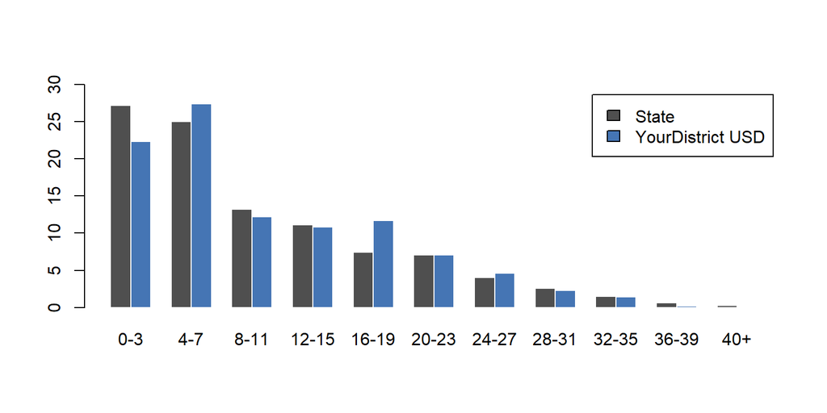

### Years Teaching in District

**State**, N = 2,585

**YourDistrict USD**, N = 1,448

Years in District, %

0-3

27%

22%

4-7

25%

27%

8-11

13%

12%

12-15

11%

11%

16-19

7.4%

12%

20-23

7.1%

7.1%

24-27

4.0%

4.6%

28-31

2.6%

2.3%

32-35

1.5%

1.4%

36-39

0.6%

0.2%

40+

0.3%

0%

(Missing)

3

0

## Worked in other district

##### Have you worked and/or taught in a district other than the one you currently work in?

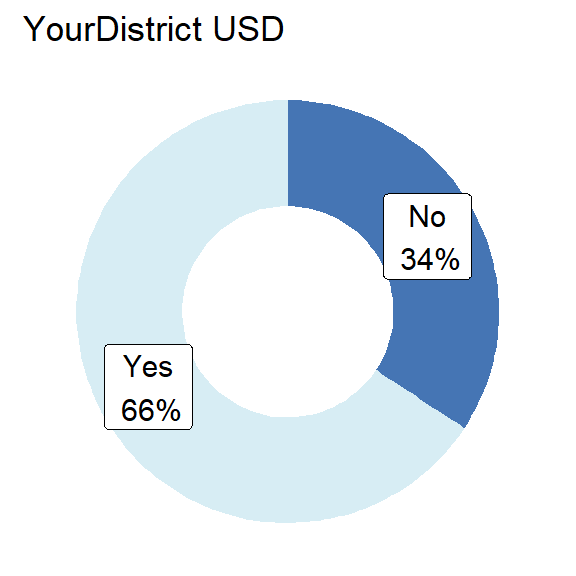

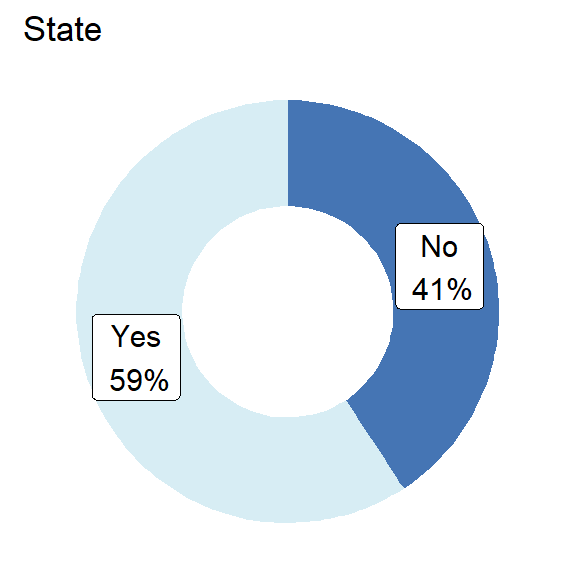

## Second Job

##### Do you hold a second job? (Not including supplemental contracts or other pay that comes from your district)

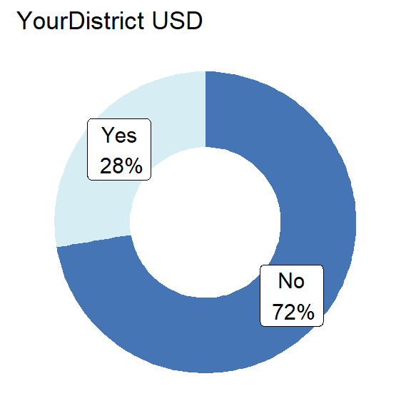

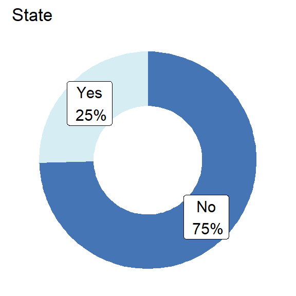

## Children in district

##### Do you have children who currently attend school within the district you teach?

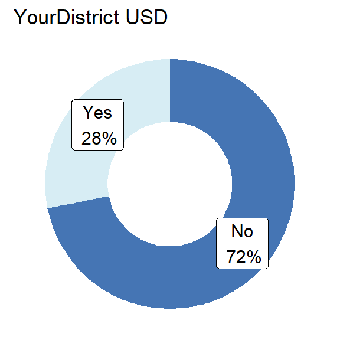

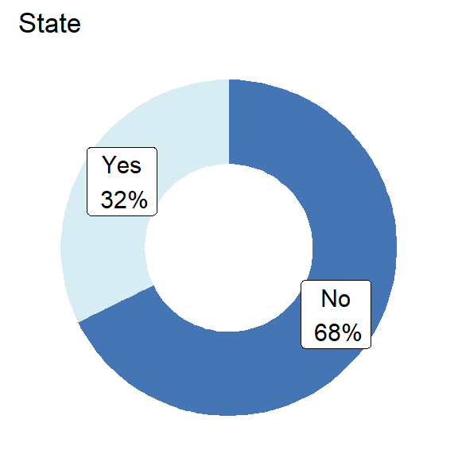

## Live within district

##### Do you teach in the same district in which you live?

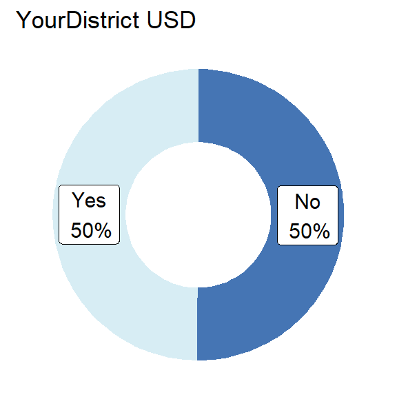

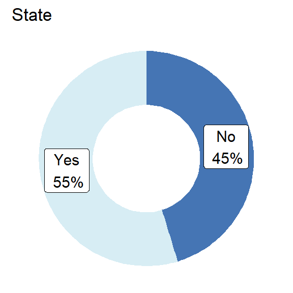

## Union membership

##### Are you a member of a professional association (union)?

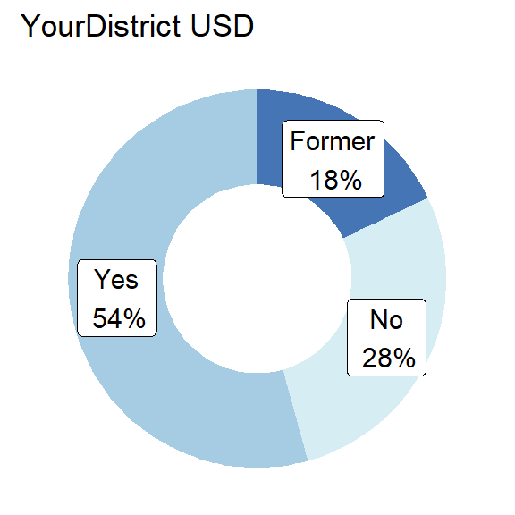

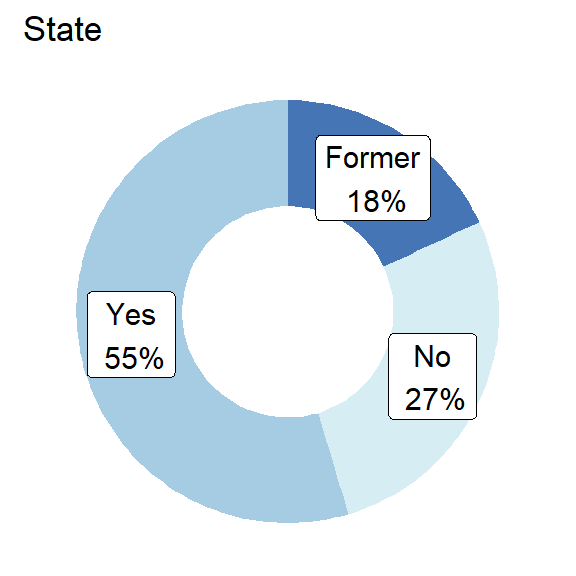

# Item Summaries

## Engagement Index

### Commitment and Focus

Engaged teachers tend to embrace teaching as their chosen profession and are committed to it.

Engagement Index

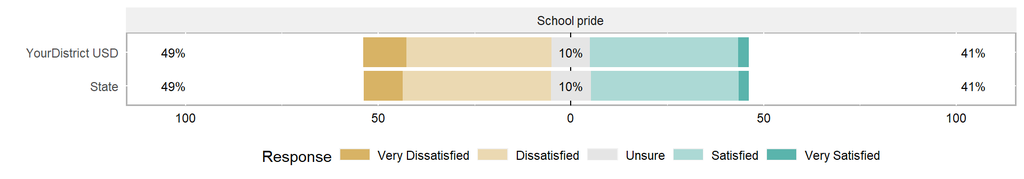

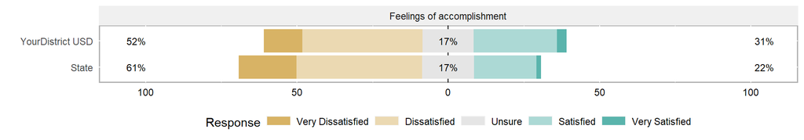

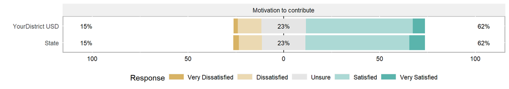

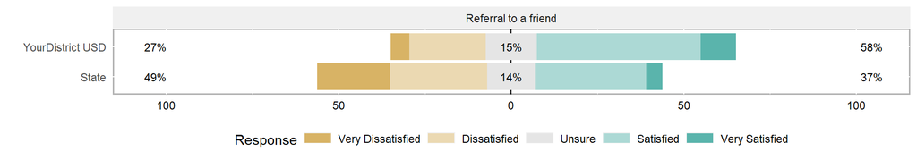

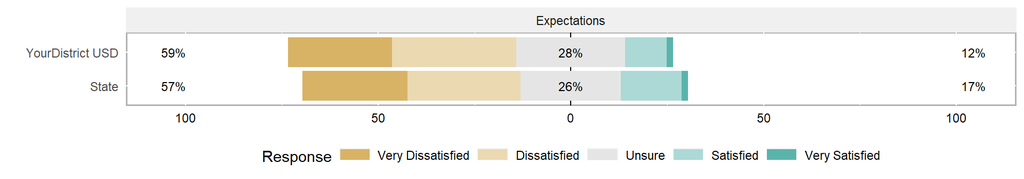

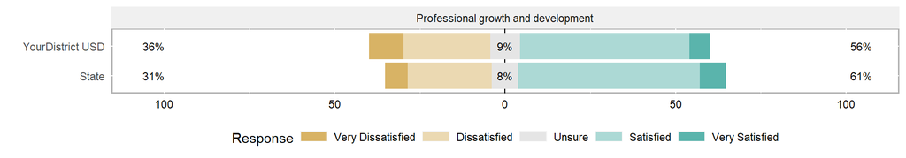

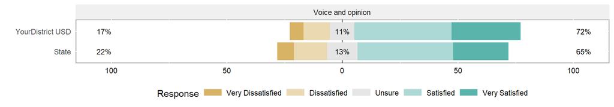

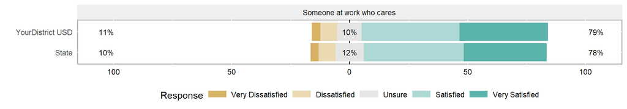

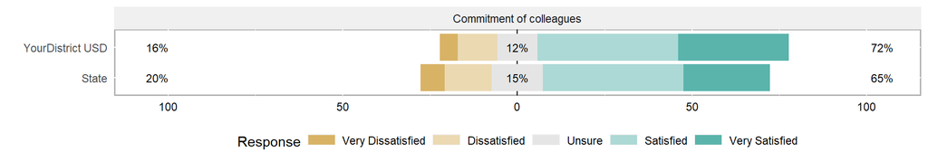

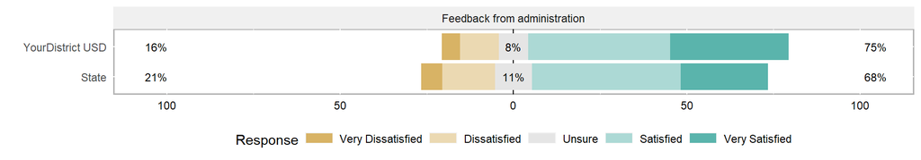

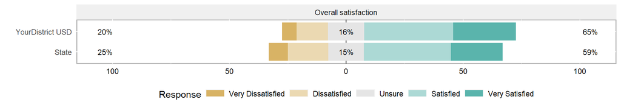